# Supplementary Data

C. Coleman

11/12/2021

*The following markdown serves as the supplementary materials for the UOWN Stream Health Indicators Project. Included materials are all figures relevant to my manuscript and were derived from the analysis code.*

*Load needed libraries*

```r
library(knitr)    # For knitting document and include_graphics function
library(ggplot2)  # For plotting
library(png)      # For grabbing the dimensions of png files
```

*Figure 1: Plots of biological score versus conductivity, E. coli cfu, nitrate concentration, and turbidity for the MIDO site.*

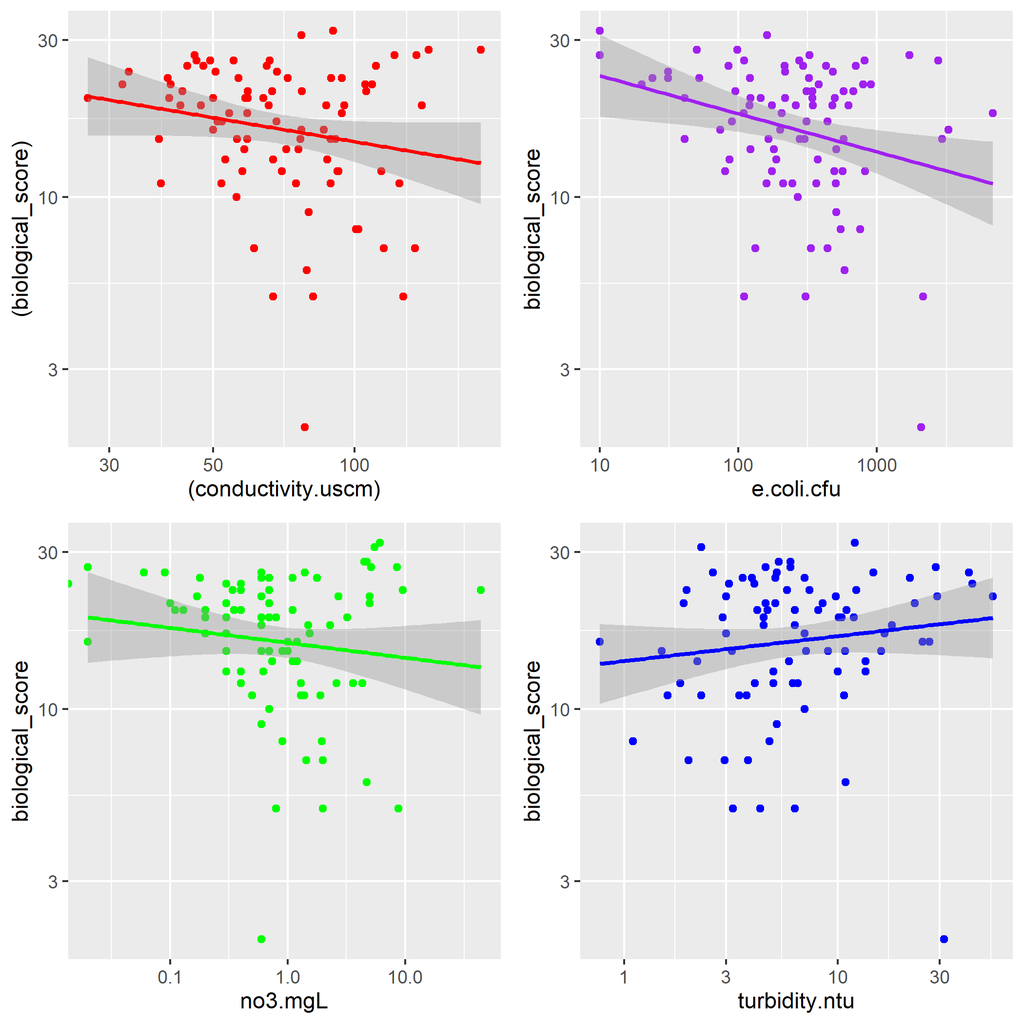

```r
bs_MIDO_location <- here::here("results", "MIDO_bs_lm.png")

include_graphics(bs_MIDO_location)
```

*Figure 2: Plots of E. coli cfu versus conductivity, nitrate concentration, and turbidity for the MIDO site.*

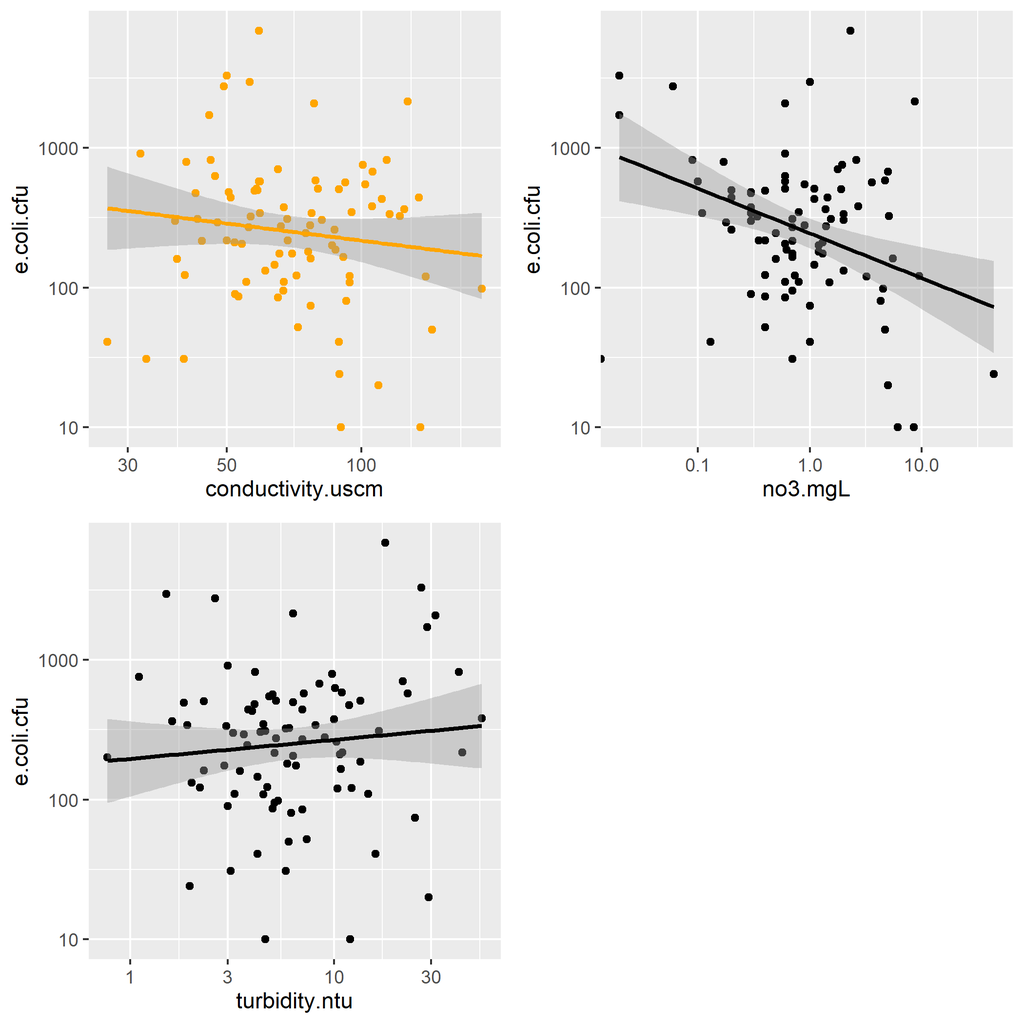

```r
ecfu_MIDO_location <- here::here("results", "MIDO_ecfu_lm.png")

include_graphics(ecfu_MIDO_location)
```

*Figure 3: Plots of biological score versus conductivity, E. coli cfu, nitrate concentration, and turbidity for the NORO site.*

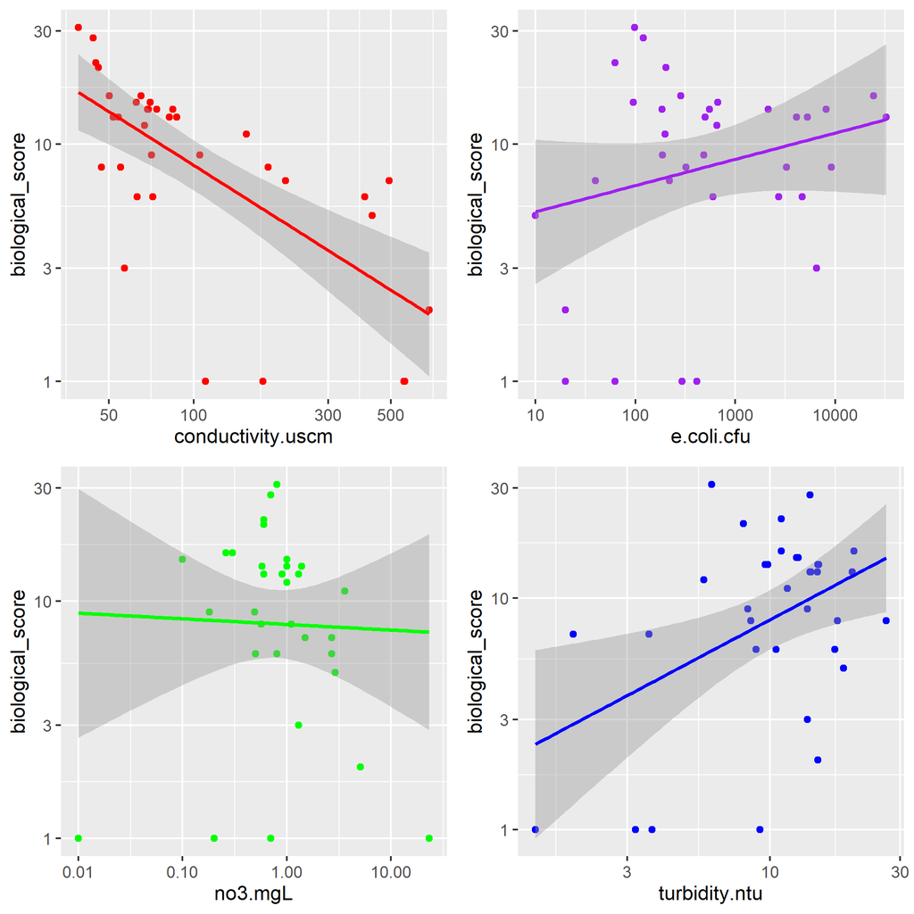

```r
bs_NORO_location <- here::here("results", "NORO_bs_lm.png")

include_graphics(bs_NORO_location)
```

*Figure 4: Plots of E. coli cfu versus conductivity, nitrate concentration, and turbidity for the NORO site.*

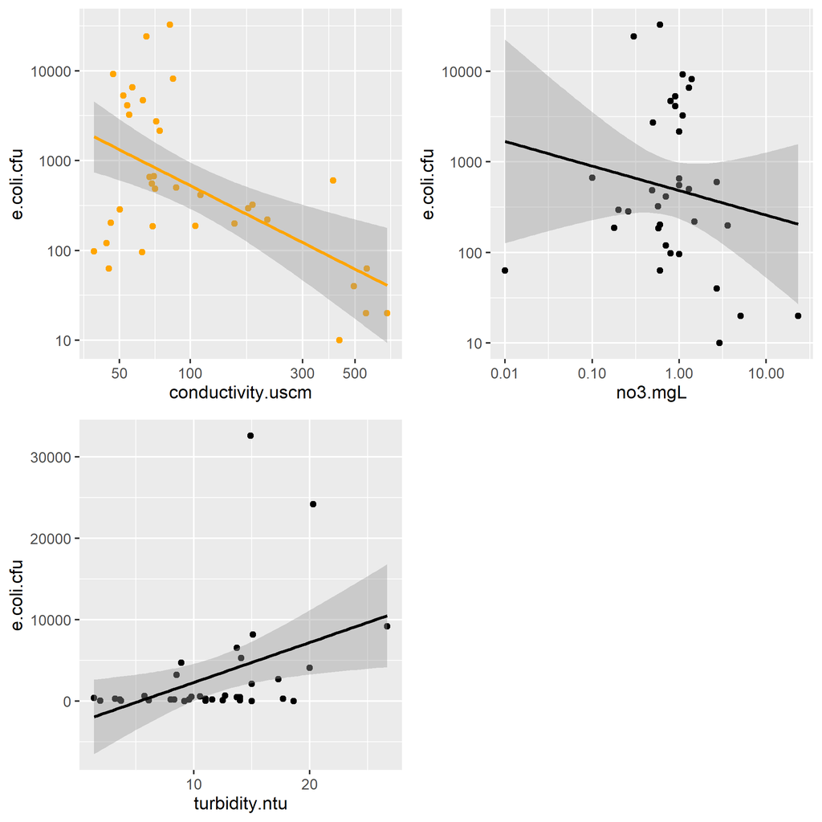

```r
ecfu_NORO_location <- here::here("results", "NORO_ecfu_lm.png")

include_graphics(ecfu_NORO_location)
```

*Figure 5: Plots of biological score versus conductivity, E. coli cfu, nitrate concentration, and turbidity for the BICO site.*

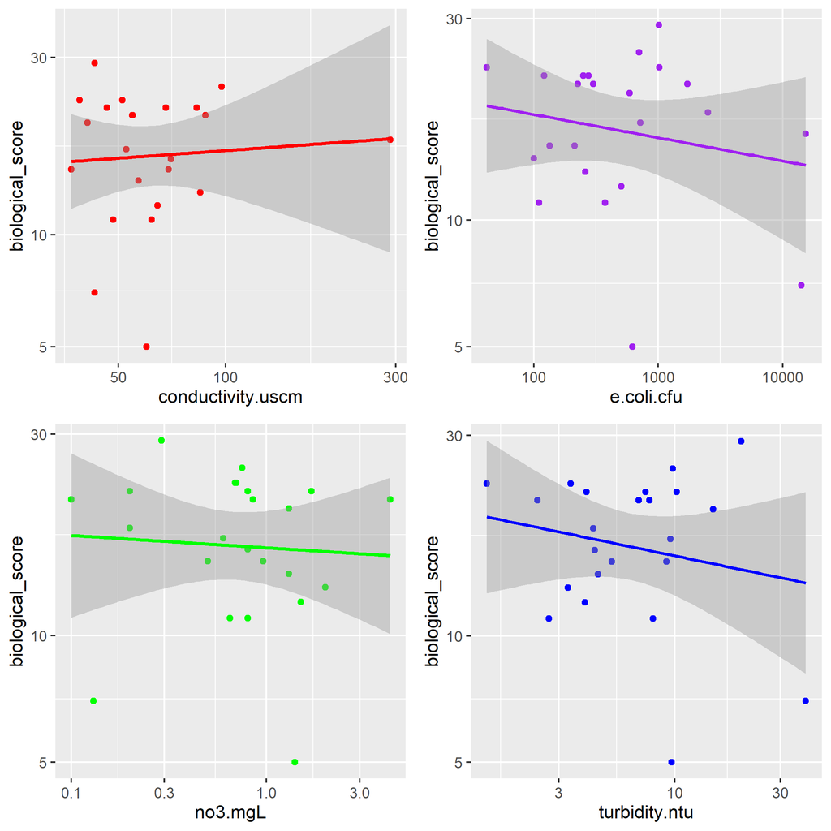

```r
bs_BICO_location <- here::here("results", "BICO_bs_lm.png")

include_graphics(bs_BICO_location)
```

*Figure 6: Plots of E. coli cfu versus conductivity, nitrate concentration, and turbidity for the BICO site.*

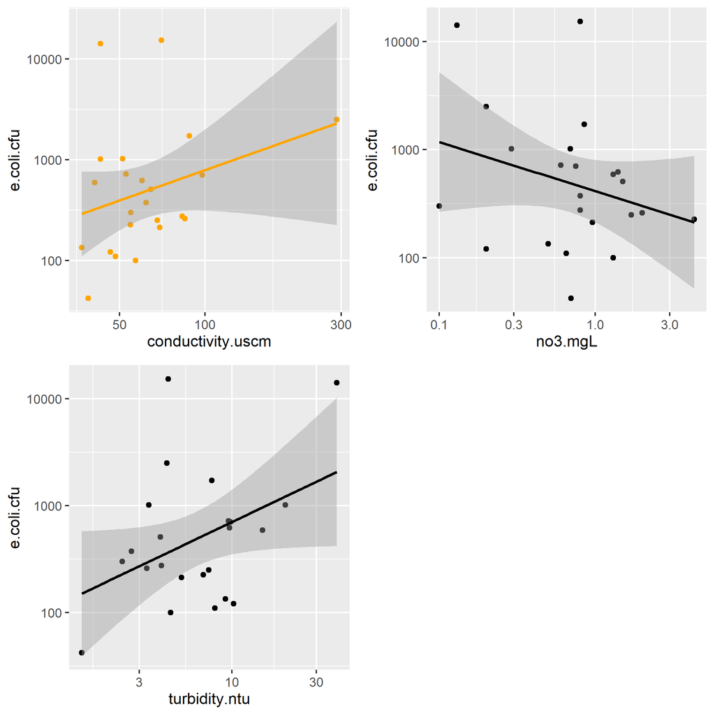

```r
ecfu_BICO_location <- here::here("results", "BICO_ecfu_lm.png")

include_graphics(ecfu_BICO_location)
```

*Figure 7: Scatter plot of LASSO model predicted Biological Score data as a function of actual Biological Score from the MIDO data set.*

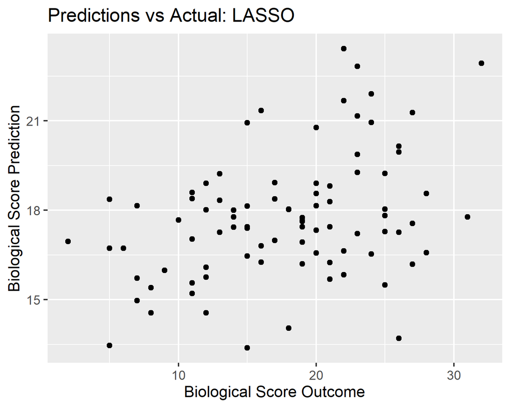

```r
lasso_prediction_plot_BS_location <- here::here("results", "lasso_prediction_plot_BS.png")

include_graphics(lasso_prediction_plot_BS_location)
```

*Figure 8: Scatter plot of LASSO model predicted E. coli cfu data as a function of actual E. coli cfu from the MIDO data set.*

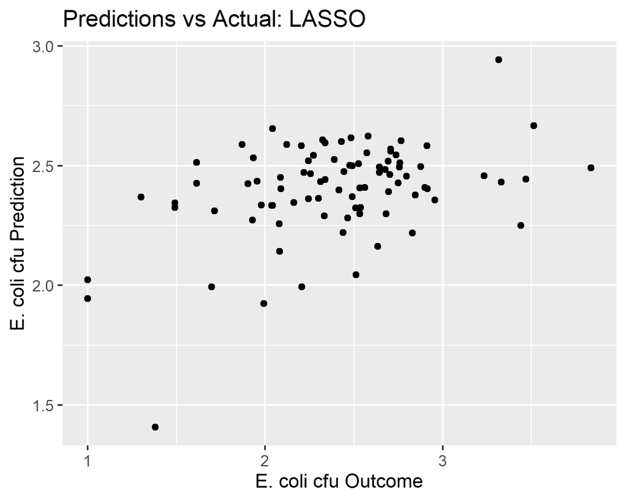

```r
lasso_prediction_plot_EC_location <- here::here("results", "lasso_prediction_plot_EC.png")

include_graphics(lasso_prediction_plot_EC_location)
```

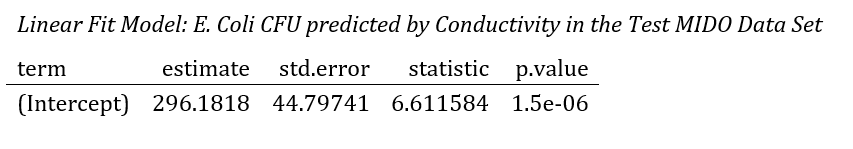

```r
MIDO_ecfu_con_fit_location <- here::here("results", "MIDO_ecfu_con_fit.png")

include_graphics(MIDO_ecfu_con_fit_location)
```

*Table 1*

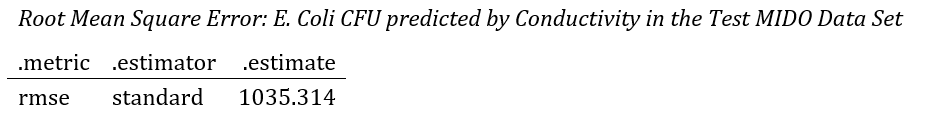

```r
MIDO_ecfu_con_RMSE_location <- here::here("results", "MIDO_ecfu_con_RMSE.png")

include_graphics(MIDO_ecfu_con_RMSE_location)
```

*Table 2*

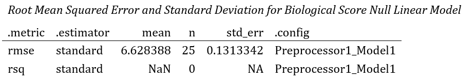

```r
Null_bs_RMSE_location <- here::here("results", "Null_bs_RMSE.png")

include_graphics(Null_bs_RMSE_location)
```

*Table 3*

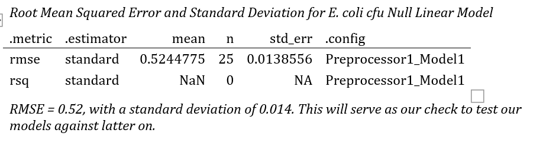

```r
Null_ecfu_RMSE_location <- here::here("results", "Null_ecfu_RMSE.png")

include_graphics(Null_ecfu_RMSE_location)
```

*Table 4*

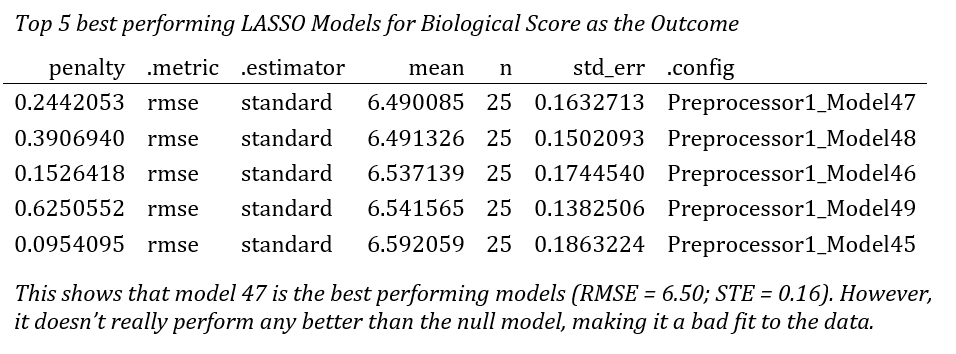

```r
MIDO_bs_LASSO_top5_location <- here::here("results", "MIDO_bs_LASSO_top5.png")

include_graphics(MIDO_bs_LASSO_top5_location)
```

*Table 5*

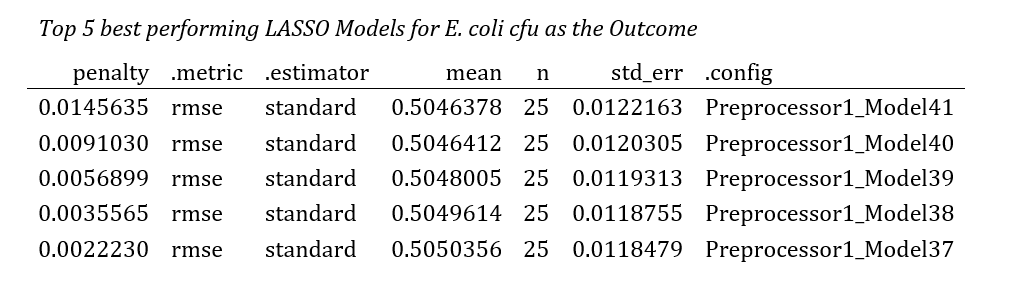

```r
MIDO_ecfu_LASSO_top5_location <- here::here("results", "MIDO_ecfu_LASSO_top5.png")

include_graphics(MIDO_ecfu_LASSO_top5_location)
```

*table 6*